# Statistic_Project1

Syuan-Bo,Huang

2022/4/7

```r
knitr::opts_chunk$set(echo = TRUE)
```

## 資料簡介

#### **Title**：the amount of page views for the top 1,000 websites on the Internet as of 2011

Focus on 5 columns

1. **Rank**: 網站排名
2. **PageViews**: 該網站一年總瀏覽次數(我們要預測的資料)
3. **UniqueVisitors**: 該網站一年不重複人次的瀏覽次數
4. **HasAdvertising**: 該網站有無廣告
5. **IsEnglish**: 該網站的主要語言是否為英文

```r
top.1000.sites <- read.csv('https://raw.githubusercontent.com/johnmyleswhite/ML_for_Hackers/master/05-Regression/data/top_1000_sites.tsv' ,sep = '\t',stringsAsFactors = FALSE)
head(top.1000.sites[,c(1,4,6,7,8)],n=10)
```

```
##    Rank UniqueVisitors PageViews HasAdvertising InEnglish
## 1     1      880000000   9.1e+11            Yes       Yes
## 2     2      800000000   1.0e+11            Yes       Yes
## 3     3      660000000   7.7e+10            Yes       Yes
## 4     4      550000000   3.6e+10            Yes       Yes
## 5     5      490000000   7.0e+09             No       Yes
## 6     6      450000000   1.5e+10            Yes       Yes
## 7     7      410000000   5.4e+09            Yes       Yes
## 8     8      340000000   1.1e+11            Yes        No
## 9     9      340000000   1.1e+10            Yes       Yes
## 10   10      340000000   2.7e+09            Yes       Yes
```

## 分析概念及步驟說明

PageViews是預測的對象 開始做迴歸分析之前，先繪製 **PageViews** 與 **UniqueVistors** 間的**散布圖**，觀察兩者數值資料是否呈現性關係。

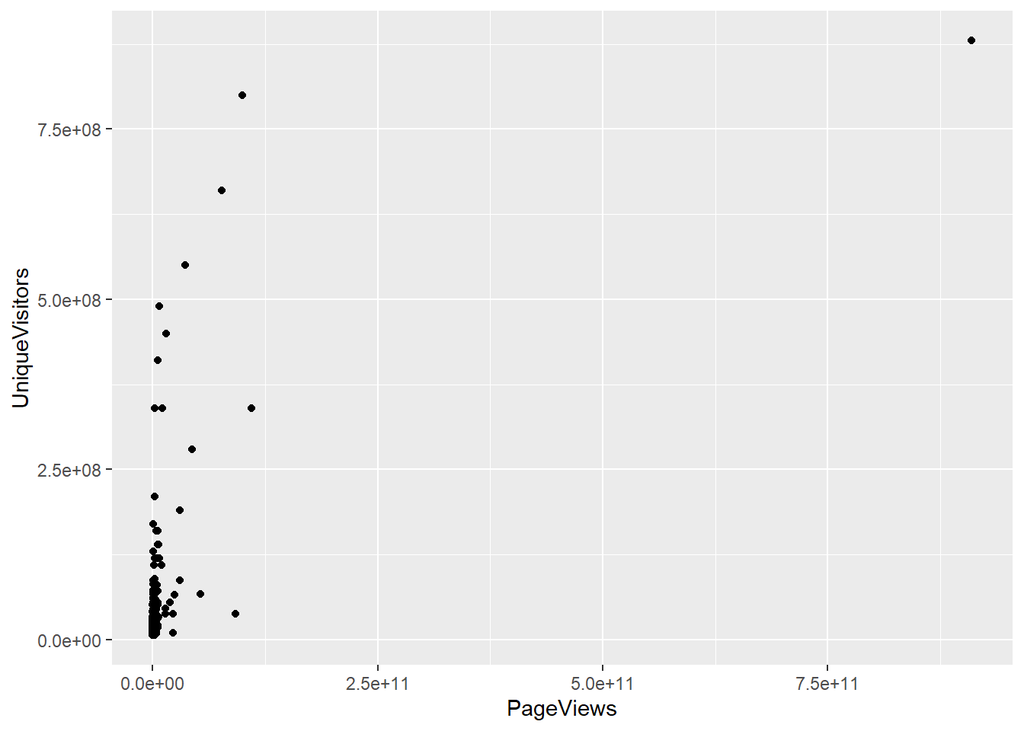

由上圖可發現兩者線性關係薄弱，從資料分布狀況推測為圖面比例尺問題，導致大部分資料集中於圖面左下角。 接著單獨觀察 **PageViews** 的資料分布情形。

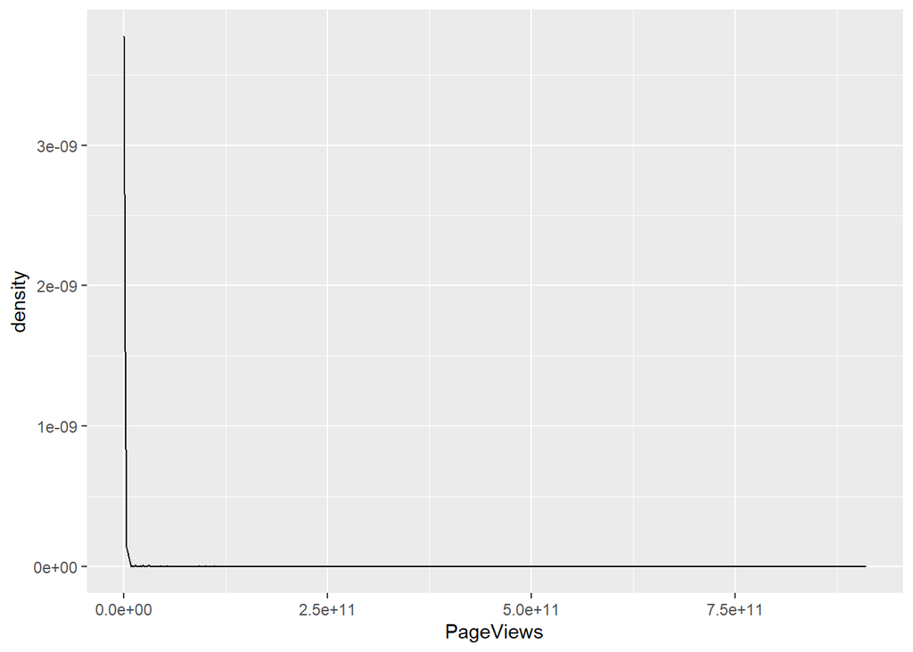

```r
ggplot(top.1000.sites,aes(x=PageViews))+geom_density()
```

結果呈現出無意義的密度圖，嘗試使用log轉換後的值繪製密度圖。

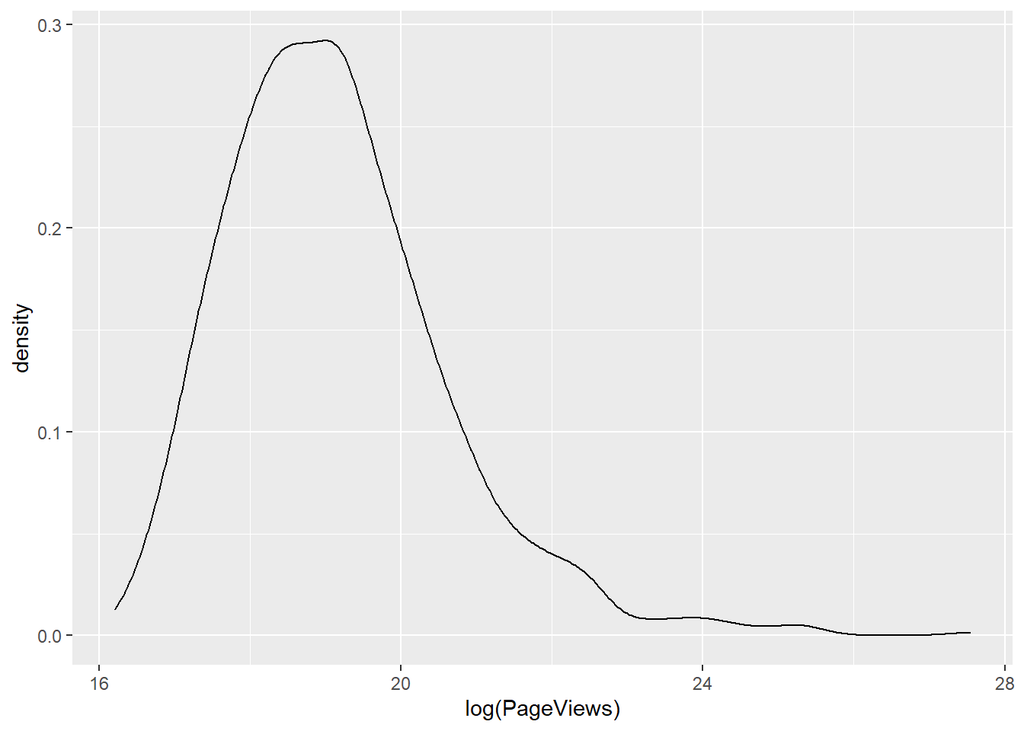

```r
ggplot(top.1000.sites,aes(x=log(PageViews)))+geom_density()
```

呈現密度圖較合乎邏輯，因此接下來採用log轉換後的PageViews和UniqueVisitors進行分析。 重新製作兩者間log轉換後的散佈圖。

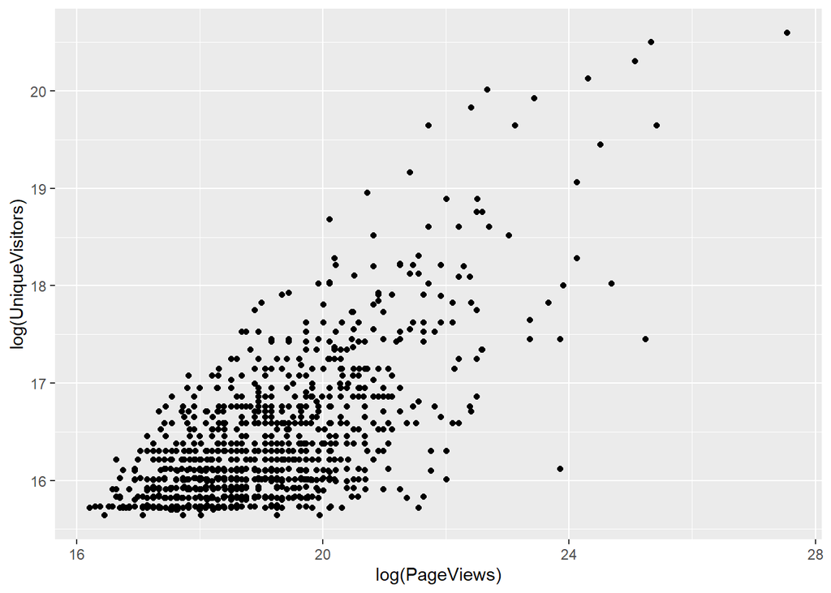

```r
ggplot(top.1000.sites,aes(x=log(PageViews),y=log(UniqueVisitors)))+geom_point()
```

其散佈結果呈現線性關係，使用method ’lm’去描繪迴歸線

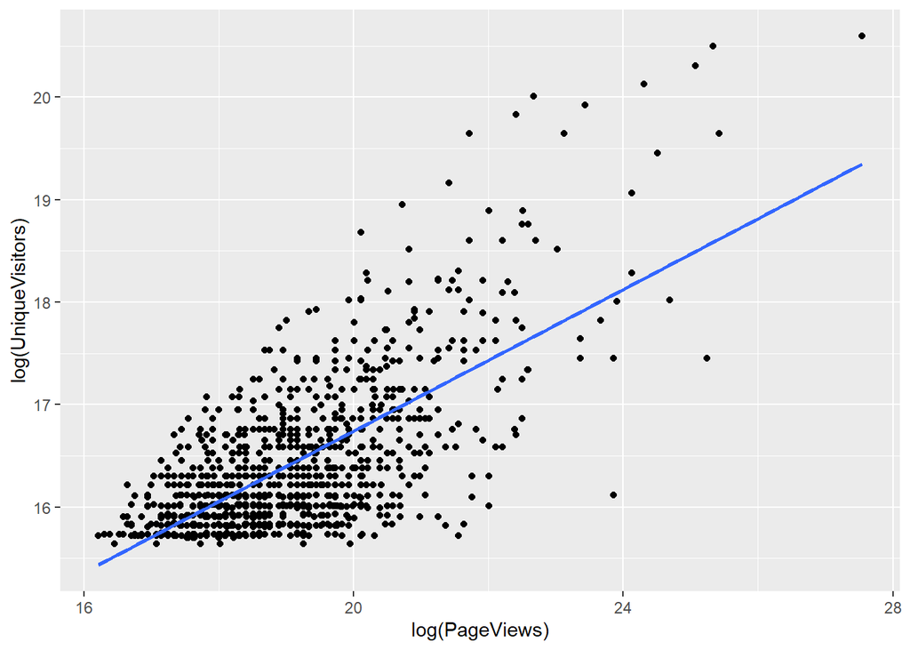

```r
ggplot(top.1000.sites, aes(x =log(PageViews),y=log(UniqueVisitors))) +geom_point()+geom_smooth(method = 'lm', se = FALSE)
```

## 分析結果

使用summary function做迴歸分析計算並總結分析結果

```r
lm.fit <- lm(log(PageViews) ~ log(UniqueVisitors),
data = top.1000.sites)
summary(lm.fit)
```

```
##
## Call:
## lm(formula = log(PageViews) ~ log(UniqueVisitors), data = top.1000.sites)
##
## Residuals:
##     Min      1Q  Median      3Q     Max
## -2.1825 -0.7986 -0.0741  0.6467  5.1549
##
## Coefficients:
##                     Estimate Std. Error t value Pr(>|t|)
## (Intercept)         -2.83441    0.75201  -3.769 0.000173 ***
## log(UniqueVisitors)  1.33628    0.04568  29.251  < 2e-16 ***
## ---
## Signif. codes:  0 '***' 0.001 '**' 0.01 '*' 0.05 '.' 0.1 ' ' 1
##
## Residual standard error: 1.084 on 998 degrees of freedom
## Multiple R-squared:  0.4616, Adjusted R-squared:  0.4611
## F-statistic: 855.6 on 1 and 998 DF,  p-value: < 2.2e-16
```

log(UniqueVisitor)的t-value為29.251(coef/std)，遠大於2，且p-value為2*10**-16小於0.001，不大於0.05，因此log(UniqeiVisitors)的係數非0，表示log(UniqueVisitors)和log(PageViews)兩者間呈線性關係。 兩者的R square值為0.4616，表示這個線性迴歸模型對這筆資料有46%的解釋性，表現還不錯。 最後F-statistic的值為855.6，遠大於1，表示拒絕係數等於0的虛無假設，代表至少存在一個不為0的係數。

接者觀察加入HasAdvertising和IsEnglish後的關係

```r
lm.fit <- lm(log(PageViews) ~ HasAdvertising + log(UniqueVisitors) + InEnglish,
data = top.1000.sites)
summary(lm.fit)
```

```
##
## Call:
## lm(formula = log(PageViews) ~ HasAdvertising + log(UniqueVisitors) +
##     InEnglish, data = top.1000.sites)
##
## Residuals:
##     Min      1Q  Median      3Q     Max
## -2.4283 -0.7685 -0.0632  0.6298  5.4133
##
## Coefficients:
##                     Estimate Std. Error t value Pr(>|t|)
## (Intercept)         -1.94502    1.14777  -1.695  0.09046 .
## HasAdvertisingYes    0.30595    0.09170   3.336  0.00088 ***
## log(UniqueVisitors)  1.26507    0.07053  17.936  < 2e-16 ***
## InEnglishNo          0.83468    0.20860   4.001 6.77e-05 ***
## InEnglishYes        -0.16913    0.20424  -0.828  0.40780
## ---
## Signif. codes:  0 '***' 0.001 '**' 0.01 '*' 0.05 '.' 0.1 ' ' 1
##
## Residual standard error: 1.067 on 995 degrees of freedom
## Multiple R-squared:  0.4798, Adjusted R-squared:  0.4777
## F-statistic: 229.4 on 4 and 995 DF,  p-value: < 2.2e-16
```

```r
lm.fit <- lm(log(PageViews) ~ HasAdvertising,
data = top.1000.sites)
summary(lm.fit)$r.squared
```

```
## [1] 0.01073766
```

```r
lm.fit <- lm(log(PageViews) ~ log(UniqueVisitors),
data = top.1000.sites)
summary(lm.fit)$r.squared
```

```
## [1] 0.4615985
```

```r
lm.fit <- lm(log(PageViews) ~ InEnglish,
data = top.1000.sites)
summary(lm.fit)$r.squared
```

```
## [1] 0.3043425
```

## Referance

- Drew Conway and John Myles White (2012) Machine Learning for Hackers, 1st Edition, O’Reilly, Sebastopol, CA.